# Quarto Crash Course

Stat 184

Author

Neil J. Hatfield

Published

December 3, 2024

Modified

November 7, 2025

This guide serves as a quick place to look for how to do different things when making Quarto documents. Keep in mind that part of Open Science is creating reproducible work. Quarto provides a great way to achieve that aim.

**Note**

This guide is not meant to be an all-inclusive, answer every question, show how to do everything guide. Rather this guide is meant to give you some quick highlights for going about several common tasks.

# 1 YAML

YAML may be interpreted as either “Yet Another Markup Language” or “YAML Ain’t Markup Language”. YAML is a programming language that typically is for writing configuration files. For a Quarto document, YAML allows us to specify several key elements including **document metadata** and **output file specifications**.

## 1.1 Core Elements

YAML is meant to be human readable. YAML uses whitespace and indentation to structure the the code and works off a principle of `key:value`. The `key` is generally some pre-defined element that we want to pass the `value` to. Keep in mind that YAML is generally *case sensitive*.

**Tip**

Working in the RStudio Desktop IDE will provide you with auto-complete for YAML keys as well as allowed values. Use them to your advantage!

When working with YAML in a Quarto document, a good practice is to make sure that the YAML header is at the very top of the QMD file. Further, the YAML header needs to *begin and end* with lines that contain just three dashes: `---`.

The following code block (Listing 1) shows the YAML header that was used for this file.

Listing 1: Quarto Crash Course YAML Header

````markdown
```{yaml}
---
title: "Quarto Crash Course"
subtitle: "Stat 184"
author: "Neil J. Hatfield"
date: "Dec. 3, 2024"
date-modified: now
format:
  html:
    embed-resources: true
    number-sections: true
    toc: true
    toc-depth: 4
    toc-location: right
    fig-align: center
    cap-location: top
    link-external-newwindow: true
execute:
  echo: false
  warning: false
csl: apa7.csl
bibliography: references.bib
---
```
````

**Caution**

You’ll notice that the YAML Header examples start with ```{yaml} and end with ```. This is a quirk of getting the YAML Headers to appear as code. You should delete/remove anything before the first three dashes and after the last three dashes that begin and end the header.

The `title`, `subtitle`, `author`, `date`, and `date-modified` keys all provide meta-data for the Quarto document.

The `format` key starts the specifications for how the output files will get generated. In Listing 1, I’m customizing the `html` output with additional keys including using section numbering, including a table of contents (`toc`), and controlling how figures and captions should appear by default. For HTML documents, you can also specify how links should work; here I’m making sure that they open up in new tabs/windows instead of replacing this guide.

Notice that the the `html` key is indented in two spaces from the `format` key and then the sub-keys to `html` are indented a further two spaces in Listing 1. When you are working with sub-keys you need to make sure that you use indentation to help communicate that structure in your YAML code.

The last set of keys that starts with the `execute` control the defaults for code chunks. Here, I’ve set the code chunks to *not* print themselves (i.e., `echo`) and to suppress any warning messages.

**Warning**

As you draft your documents you might start out with `warning: true` and then as you reach the end of the drafting cycle switch to `warning: false`. This will help you see any warnings that R produces for your code so that you address any potential issues.

**Important**

While there is a sub key of `error` you can use within the `execute`, you should avoid ever using this key to hide error messages. You should always see and address any error messages that get generated in your Quarto document.

## 1.2 Examples

The following examples provide you with some starter YAML headers. You can customize these as needed.

**Tip**

**ALWAYS** check with your course instructor or supervisor for what output file and formatting they want.

### 1.2.1 Using Default Output Formats

Taking a moment to think through what type of output format(s) you want is always a good thing. This fits with the **Planning** stage of the PCIP System. If the default file formats are all you want, then you can simplify your YAML header. Here are the `key: value` pairs of the three common default output file types:

- HTML: `format: html`
- PDF: `format: pdf`
- Word Doc: `format: docx`

If you want Quarto to create *multiple* output file types from the same document, you use the `format` key to do this. Listing 2 shows a basic example for creating three different output files from one Quarto document.

Listing 2: Multi-output YAML Example

````markdown
```{yaml}
---
title: "Example Document"
format:
  html: default
  pdf: default
  docx: default
---
```
````

When specifying multiple output files, you will need to set each output type on their own line and use the `default` value *if* you are not otherwise specifying additional formatting guides. You can combine the following examples along with the Listing 2.

**Note**

When creating multiple output files from a single Quarto document, the Render button of RStudio Desktop will only create the first listed output. However, you can use the Terminal to have Quarto generate all output formats. You will either need to make sure that the Terminal is pointed to the folder that your QMD file is in OR provide the full file path. Then, all you need to do is run the following code:  
`quarto render exampleQuarto.qmd`.

### 1.2.2 HTML w/Code Appendix

If you are planning on including a code appendix (see Section 8) in your document, then you do not need to show the code in the body of your document. The following YAML header example (Listing 3) serves as a good starting point for HTML output in such a situation.

Listing 3: Recommended YAML Header for HTML Output Format w/Code Appendix

````markdown
```{yaml}
---
title: "Informative Title"
author: "List All Authors"
date: "Dec. 3, 2024"
date-modified: now
format:
  html:
    embed-resources: true
    number-sections: true
    toc: true
    toc-depth: 4
    toc-location: right
    fig-align: center
    cap-location: top
    link-external-newwindow: true
execute:
  echo: false
  warning: false
---
```
````

### 1.2.3 HTML w/Code Folding

In the event that you *are not* including a code appendix or you want to allow users to see code chunks in context, then you should set up code folding. This example (Listing 4) will give a good starting point for that.

Listing 4: Recommended YAML Header for HTML Output Format w/Code Folding

````markdown
```{yaml}
---
title: "Informative Title"
author: "List All Authors"
date: "Dec. 3, 2024"
date-modified: now
format:
  html:
    embed-resources: true
    number-sections: true
    toc: true
    toc-depth: 4
    toc-location: right
    fig-align: center
    cap-location: top
    link-external-newwindow: true
    code-fold: true
execute:
  warning: false
---
```
````

Notice that you’ll need to add the `code-fold` key AND remove the `echo` key.

### 1.2.4 PDF

Generally, if you are making a report as a PDF, your code should appear in an appendix at the end of the document, not in the body of your report.

Listing 5: Recommend YAML Header for PDF Output

````markdown
```{yaml}
---
title: "Informative Title"
author: "List All Authors"
date: "Dec. 3, 2024"
date-modified: now
format:
  pdf:
    toc: false
    number-sections: true
    number-depth: 5
    fig-align: center
    cap-location: top
    geometry:
      - top=1in
      - left=1in
      - right=1in
      - bottom=1in
    colorlinks: true
execute:
  echo: false
  warning: false
---
```
````

When creating a PDF, always check to see if you need a Table of Contents and adjust the `toc` key’s value as appropriate (Listing 5). The `geometry` key allows you define the page margins. Here, I’ve used 1-inch margins on all sides.

#### 1.2.4.1 LaTeX Needed

If you are creating a PDF from a Quarto document, you’ll need to have LaTeX installed on your computer. The easiest way to do this is to use TinyTex. The `{tinytex}` R package will help you install the necessary components.

Listing 6: R Code for Setting Up TinyTex

```r
install.packages("tinytex")
library(tinytex)
install_tinytex()
```

Running the commands shown in Listing 6 in your Console will trigger a process to get LaTeX installed and configured for rendering Quarto documents to PDF. Be sure to follow the prompts as they come up. Keep in mind that the first time you render to a PDF, the process will take a bit longer than usual.

### 1.2.5 Word

When going to a Microsoft Word document (*.docx), you’ll want to make sure that you do a careful look through the rendered output file to make sure that everything appears how you intended. Be prepared for the need to make adjustments. Listing 7 shows a recommended YAML Header.

Listing 7: Recommend YAML Header for Word Document Output

````markdown
```{yaml}
---
title: "Informative Title"
author: "List All Authors"
date: "Dec. 3, 2024"
date-modified: now
format:
  docx:
    toc: false
    toc-depth: 5
    number-sections: true
    number-depth: 5
    page-width: 6.5
    fig-align: center
    fig-dpi: 300
execute:
  echo: false
  warning: false
---
```
````

As with PDFs, always check to see if a Table of Contents is needed. The `page-width` key is how you’ll specify the left/right margins (symmetric) for the document. A new key to be sure to set is `fig-dpi`; this controls the resolution of graphics. Set this too low and your visualizations will appear grainy/fuzzy. The recommendation is to use at least 300.

## 1.3 Exceptions

Keep in mind that the formatting keys in your YAML header will act as the *defaults* for your document. You can always override those options for individual pieces. For instance, you can set the default for code chunks to not print themselves (i.e., `echo: false`) but then have a particular code chunk print itself. These overrides are best done within individual code chunks.

# 2 Formatting Narrative Text

Beyond the YAML header, there are two other essential portions to Quarto files: **narrative text** and **(reproducible) code**. This section focuses on how you format/style your narrative text.

There are two approaches you can take to format/style your narrative text. In class, you saw how to do this using RStudio Desktop’s Visual editor. This displays your document in a What-You-See-Is-What-You-Get (WYSIWYG) style simple editor that has buttons much like what you have in MyOpenMath for essay questions or might encounter in Google Docs. For this guide, I’m going to show how to format your text when you are in the Source view of a Quarto document. (This approach will also work if you are using another IDE that doesn’t support a visual editor.) Your formatting draws upon Markdown syntax.

**Tip**

Markdown syntax also works on GitHub. This includes Markdown files (e.g., readme.md), commit messages, issues, pull request details, etc.

## 2.1 Headings

Many students often think about headings as being a stylistic element and to a certain extent this is true. However, headings also serve an important structural purpose: headings help readers build their sense of how the different parts of the document connect to each other in a hierarchical fashion. Throughout this guide, I’ve been using (numbered) headings to communicate the guide’s structure and help you get a sense of what each section might be about.

Section headings are essentially hashtags. That is, they are short, descriptive phrases that start with one or more hash signs (a.k.a. pound signs, octothropes). The number of hashes you place at the start of the line will determine the heading level. One hash gives Heading Level 1; two will give Heading Level 2, etc. If you used the `number-sections: true` in your YMAL header, the Heading Level controls the automatic numbering of your sections.

Keep in mind that just like hashtags, section headings *are not* meant to be full sentences and **definitely not** supposed to multiple lines long. Unlike hashtags that you find online, you will want to put spaces between words and use the appropriate case (Title, Sentence) for your document style (e.g., APA). There should be a space between the hashes and the first word of the heading.

Section headings follow a hierarchy with Heading Level 1 being the top level; Heading Level 2 is the next level down, and so forth. While you can get down to Heading Levels 5 and 6, please try to keep these to a minimum. We also do not want to skip any levels. That is, don’t use a Heading Level 3 after a Heading Level 1 but not have anything that is a Heading Level 2. This is as much for ensuring the accessibility of your document as well as helping to make sure that the auto-numbering makes sense to your readers.

## 2.2 Styling Text

Beyond creating headings, we can also style text. The most common text styling includes *italics*, **boldface**, creating lists, and adding links.

### 2.2.1 Italicizing Text

The most common usages of italics are when you are introducing a key term for the first time or when you want to add emphasis to a word or phrase. To italicize a word or phrase, you’ll need to place a single asterisk, *, on both sides of the word/phrase. For example, *sample arithmetic mean* will get rendered as *sample arithmetic mean* in the render/knitted document.

### 2.2.2 Bolding Text

Boldface text also places emphasis on a word or phrase and can be used to call out particular words or phrases in your writing. To make a word or phrase bold, you’ll need to type two underscores. _ _ (with no space between them) on both sides of the word/phrase. For example, _ _ NASA_ _ becomes **NASA** in the final output.

**Note**

In Markdown you can also use two asterisks on either side of a term to get boldface. For example, **NASA** will also make **NASA**.

### 2.2.3 Lists

There are several different kinds of lists but the two most common are bulleted (a.k.a. unordered lists) and numbered (a.k.a. ordered lists). The major difference between the two is whether you want to convey to the reader that list elements need to be done in a specific order (i.e., ordered lists) or in any order (i.e., unordered lists).

To create a list, you’ll want to move down two lines from you preceding narrative text and then type either a dash (`-`) for unordered lists or a numeral followed by a period (e.g., `1.`) for ordered lists. You will want to have an empty line after the last element in your list before starting your next block of test. Here are two examples.

- Apples
- Oranges
- Bananas
1. Wake up
2. Have breakfast
3. Get ready for the day

### 2.2.4 Links

You can add links to your text (as appropriate) by enclosing the link text in square brackets ([ and ]) and then immediately placing the URL link inside a set of parentheses after the last square braket (no spaces). For example, the text “[Markdown Cheat Sheet](https://www.markdownguide.org/cheat-sheet/)” will get rendered as [Markdown Cheat Sheet](https://www.markdownguide.org/cheat-sheet/) (*Markdown Cheat Sheet | Markdown Guide*, n.d.).

If you want to see further ways to style text, check out the aforementioned Markdown cheat sheet.

# 3 Writing Mathematics

When working in quantitative fields like Statistics and Data Science, we often find ourselves needing to type mathematical expressions or formula. Quarto allows us to include mathematics in our narrative text in one of two formats: inline math and display math.

## 3.1 Inline Mathematics

Inline mathematics is meant to be displayed as part of a regular sentence. For example, we might want to report that some random variable follows a Gaussian distribution with mean $\mu=70$ and variance $\sigma^2=4.2$.

Start your inline mathematical expression by typing a single dollar sign, $, followed by your expression; end your expression with another dollar sign, $. For example, $y=x^2+\frac{3}{4}$ will become $y=x^2+\frac{3}{4}$.

If done correctly, the starting and ending dollar signs should appear as red text in the RStudio Desktop IDE Source view.

**Tip**

Need to type a dollar sign without triggering a math expression? Just preceed the dollar sign with a backslash. For example, \ $ (no space). This also works on other Markdown symbols such as the asterisk and underscore.

### 3.1.1 Greek Characters

While it might be tempting to use HTML entities for Greek characters (e.g., `&mu;`) or those found from keyboard shortcuts (e.g., µ), you need to do so with some caution. The HTML entities will *only* appear in the HTML output. The keyboard shortcut generated symbols may cause the Quarto document to fail to render (especially to PDF). The best practice is to use inline mathematics for Greek characters.

## 3.2 Display Mathematics

Display mathematics is for when you want to the mathematical expression to be centered on its own line. We use this when we really want to emphasize the formula.

To create display equations (centered on their own line), use two dollar signs to begin and end the expression. Thus, $ $y=x^2+\frac{3}{4}$ $ (no space between the dollar signs) will become
$$y=x^2+\frac{3}{4}$$

### 3.2.1 Align Environment and Multiple Lines

If you need to create mathematical expressions that span multiple lines, you can use the align environment inside a display math mode. For example,

```
\begin{align*}
H_0&: y = \mu_{\bullet\bullet} + \epsilon_{ij}\\
H_1&: y = \mu\_{\bullet\bullet} + \alpha_{i} + \epsilon_{ij}\\
end{align*}
```

will become

$$\begin{align*}
H_0&: y = \mu_{\bullet\bullet} + \epsilon_{ij}\\
H_1&: y = \mu_{\bullet\bullet} + \alpha_{i} + \epsilon_{ij}
\end{align*}$$

The ampersand, &, tells LaTeX to use align the lines that point.

**Tip**

The math display system in Quarto is connected to LaTeX (TeX). If you are familiar with that system, you can draw upon that knowledge. If you’re new to typing mathematics, no worries. Overleaf (n.d.) has a [handy guide](https://www.overleaf.com/learn/latex/List_of_Greek_letters_and_math_symbols) of Greek characters and mathematical symbols as well as a bunch of other math guides you can draw from.

# 4 Coding in Quarto

There are two ways that you can use programming languages in Quarto documents. You can run (simple) commands inline or you can write code chunks.

## 4.1 Inline Code

Inline code is great for reporting a value that you have stored in the environment, to do a quick calculation, or something else that is **simple**. To create some inline code, you’ll need to start with a backtick (or grave), `, the symbol located on the key just to the left of the 1 key. This will start your code; you’ll close the code with another instance of the backtick, `. You’ll need to type a lower case `r` right after the first backtick to state what language your code is supposed to be (in this case R). For example, ` r 1 + 2 ` will yield 3. Notice that inline code is evaluated and the result is displayed.

Inline code will automatically be run when you render the document.

## 4.2 Code Chunks

Code chunks are much larger blocks where you can do more complicated things. For example, you can use code chunks to import a picture, load and clean data, create data visualizations, tables, and run models, etc.

You can add a code chunk manually by typing three backticks in a row on new line. When you’re finished with the chunk, you type another three backticks. In the first line, just after the three backticks, you need to include a set of curly braces and list the programming language for the code. For instance `{r}`. All of your code should be on lines in between these two lines as well as any chunk options. Listing 8 shows how you should set up a code chunk for R in a Quarto document. In RStudio Desktop, you can also use the insert code chunk button (looks like a green square with a plus sign and the letter C) and select R to get a code chunk. Alternatively you can also use the keyboard shortcut Command + Option + i (Mac) or Ctrl + Alt + i (Windows).

Listing 8: Formatting a Code Chunk for R

````markdown
```{r}
#| label: exampleCode1
#| lst-label: lst-exampleChunk
#| lst-cap: "Formatting a Code Chunk for R"
#| eval: false

# A First Example Code Chunk ---
1 + 1
```
````

The four lines that start with `#|` list out the code chunk options. These follow the YAML structure of `key: value`. These code chunk options allow you to grant format exceptions from default as well as configure figure size, captions, and position.

**Warning**

Be cautious of the `eval` and `include` keys. The `eval` key controls whether or not the code chunk will run during rendering; the `include` key controls whether the *output* of the code will get included in the rendered document (the code still runs).

You can execute (run) code chunks individually by clicking the play button located in the upper-right corner of each chunk. This will display the output of the code in a collapsible window below the chunk. Keep in mind that when you run code this way, it references your current environment for items.

When you render a Quarto document, R will create a *new* environment that is separate from your local environment and run all of the code fresh. The results of that run will be what get put into the output file(s).

**Important**

A common issue students run into when working with Quarto is forgetting that rendering creates a new environment. They will often load data to their local environment *but* not have any code in their Quarto document that loads the data. Thus, when they render their Quarto file, their code fails as objects are missing.

Code chunks can be run individually by clicking the play button located in the upper right corner of each chunk. This should display the output of the code chunk in a collapsible window below the code. All code chunks will run when you knit/render the document unless you’ve specified otherwise as a chunk option.

## 4.3 Using Multiple Coding Languages

One of the powerful aspects of Quarto documents is that they support multiple programming languages within the same document. Currently, Quarto supports R, Python, Julia, and Observable JavaScript for computations. Quarto also understands HTML, YAML, CSS, and SQL (via the `{knitr}` R package).

Keep in mind that if you are going to use multiple programming languages in the same document, you *must* have the appropriate engines installed on your machine. That is, you need to have a Python installation if you plan to run Python code; R if you plan to run R code, etc.

For Python, you’ll need to install the `jupyter` package. For details, check out the [Using Python](https://quarto.org/docs/computations/python.html) page of Quarto (*Using Python*, n.d.). You will also need to add the `key: value` pair `jupyter: python3` to your YAML header or to the code chunk as shown in Listing 9.

Listing 9 shows an example code chunk that uses Python instead of R with in the Quarto document that makes this webpage.

Listing 9: An example of a python code chunk

````markdown
```{python}
#| jupyter: python3
#| lst-label: lst-python
#| lst-cap: "An example of a python code chunk"
# An example python code chunk ----
prefix = "Stat"
num = 184

statement = "Welcome to {} {}!".format(prefix, num)
print(statement)
```
````

```
Welcome to Stat 184!
```

One of the most powerful aspects of a multi-programming language document is that you can use different languages for different tasks, playing to the strengths of the tasks. In Quarto, you can pass variables between Python and R. When rendering your Quarto document to objects will get created: `py` and `r`. The `py` object contains all of your Python variables while `r` contains all of your R variables. This means that you can access and change elements using the appropriate extractor operator: `$` in R and `.` in Python.

**Caution**

Keep in mind that you still need to have all of the packages you need already installed *for all programming languages* you are using in a Quarto document. Additionally, there may still be instances where communication errors occur. Get in the habit of regularly testing and rendering the full document.

Listing 10: Calling a Python Object in R Code Chunk

````markdown
```{r}
#| lst-label: lst-py2R
#| lst-cap: "Calling a Python Object in R Code Chunk"
# Example of Call Python object in R Chunk ----
library(reticulate)
capStatement <- stringr::str_to_upper(py$statement)
print(capStatement)

# Create new R objects for next example ----
mainPart <- runif(n = 5, min = 50, max = 80)
errorPart <- rnorm(n = 5, mean = 0, sd = 1)
```
````

```
[1] "WELCOME TO STAT 184!"
```

In Listing 10, you’ll notice that we needed to load the `{reticulate}` R package. This package needs to be loaded just once in your Quarto document to facilitate passing objects between the two languages.

Listing 11: Calling R Objects in Python Code Chunk

````markdown
```{python}
#| jupyter: python3
#| lst-label: lst-R2py
#| lst-cap: "Calling R Objects in Python Code Chunk"
# Example of Calling R objects in Python ----
newValues = [sum(x) for x in zip(r.mainPart, r.errorPart)]
roundedValues = [round(x, 3) for x in newValues]
print(roundedValues)
```
````

```
[64.025, 72.153, 55.338, 69.788, 72.096]
```

Similarly, we can access and work with R objects in Python chunks (see Listing 11).

# 5 Tables and Figures

As you create reproducible analyses, you’ll want to incorporate data visualizations. This includes tables and figures (plots, graphs, images). You can make use of the code you’ve learned this semester inside Quarto documents. The new aspect is to capitalize on the appropriate code chunk options to take your visualizations to the next level.

## 5.1 Tables

To demonstrate making a table, I’m going to use the Diamond Summary Table. If you look in the Code Appendix, you’ll find the code to wrangle the Diamonds data (Wickham, 2015) but that code doesn’t appear in the body of this guide. Listing 12 shows the code block for creating a table in a Quarto document.

Listing 12: Code Chunk for Making Table

````markdown
```{r}
#| label: tbl-diamondsSummary
#| tbl-cap: "Summary Statistics on Diamond Width by Cut"
#| tbl-pos: H
#| html-table-processing: none
#| lst-label: lst-table1
#| lst-cap: "Code Chunk for Making Table"
# Make Diamond Summary Table ----
summaryWidth %>%
  kable(
    digits = 2,
    col.names = c("Cut Quality", "Freq.", "Min", "20%-tile", "40%-tile", "Median",
                  "60%-tile", "80%-tile", "Max", "SAM", "SASD"),
    format.args = list(big.mark = ","),
    align = "lcccccccccc"
  ) %>%
  kable_classic() %>%
  add_footnote(
    label = c("Width was measured in milimeters."),
    notation = "none",
    threeparttable = TRUE
  )
```
````

Table 1: Summary Statistics on Diamond Width by Cut

| Cut Quality | Freq. | Min | 20%-tile | 40%-tile | Median | 60%-tile | 80%-tile | Max | SAM | SASD |
| --- | --- | --- | --- | --- | --- | --- | --- | --- | --- | --- |
| Fair | 1,609 | 3.78 | 5.50 | 5.98 | 6.10 | 6.23 | 7.00 | 10.54 | 6.19 | 0.94 |
| Good | 4,904 | 3.84 | 4.74 | 5.63 | 5.99 | 6.23 | 6.60 | 9.38 | 5.85 | 1.05 |
| Very Good | 12,081 | 3.71 | 4.62 | 5.40 | 5.77 | 6.16 | 6.68 | 9.94 | 5.77 | 1.10 |
| Premium | 13,789 | 3.68 | 4.66 | 5.62 | 6.06 | 6.40 | 6.94 | 58.90 | 5.95 | 1.26 |
| Ideal | 21,550 | 3.73 | 4.46 | 4.97 | 5.26 | 5.72 | 6.57 | 31.80 | 5.52 | 1.07 |

Width was measured in milimeters.

There a couple of items to notice in Listing 12. First, the first two chunk options, `label` and `tbl-cap` are absolutely necessary if you want to be to cross-reference your tables. The value for `label` **MUST** begin with `tbl-`. The value for `tbl-caption` would be what you would have put as the value for the `caption` argument in the `kable` call. You do not need both. When using the `{kableExtra}` package, it is a good practice to also use the code chunk option `html-table-processing: none`. This will keep Quarto from trying to re-process the table, which can lead to odd or wonky looking tables.

When rendering the HTML, your tables will appear in same relative place in the document as the creating code chunk. The same isn’t true when you render to paginated documents (PDFs or Word). By default, Quarto’s engine will attempt to place the table (or figure) as close the relative location of the code chunk as possible but the table and and figure may end up on another page. To override this and “force” Quarto to put the table where you want, you can use the `tbl-pos: H` chunk option (tbl-pos for “table position” and H for “Here!”). Keep in mind that this option will be ignored if space that is “here” isn’t large enough for your table.

## 5.2 Figures

Code chunks that produce figures have several more chunk options that you can make use of to ensure that your figures look good. For my example here, I’m going to use the code for the popularity of Stat 184 Instructor Names from the Baby Names data set (Kaplan & Beckman, 2020).

Listing 13: Code Chunk for Making a Figure

Figure 1: Popularity of the Stat 184 Instructor’s First Names Over Time

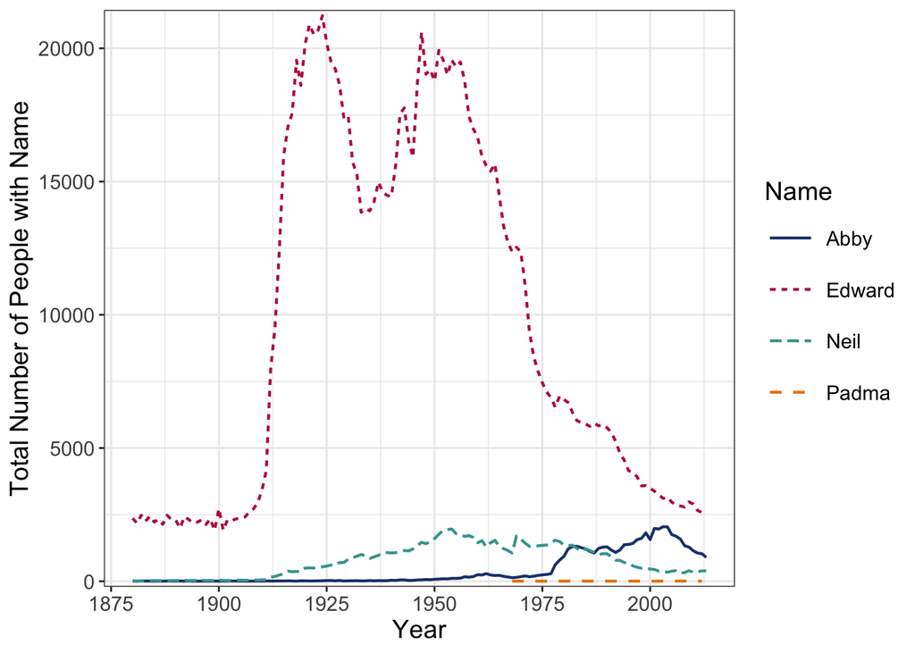

````markdown
```{r}
#| label: fig-namesPlot
#| fig-cap: "Popularity of the Stat 184 Instructor's First Names Over Time"
#| fig-pos: H
#| fig-height: 5
#| fig-alt: "Line graph showing popularity of four names over time"
#| aria-describedby: namesPlotLD
#| lst-label: lst-figure1
#| lst-cap: "Code Chunk for Making a Figure"
# Set Color Palette ----
psuPalette <- c("#1E407C", "#BC204B", "#3EA39E", "#E98300",
                "#999999", "#AC8DCE", "#F2665E", "#99CC00")

# Make Data Visualization ----
ggplot(
  data = subsetNames,
  mapping = aes(x = year, y = total, color = name, linetype = name)
) +
  geom_line(linewidth = 0.75) +
  theme_bw() +
  labs(
    x = "Year",
    y = "Total Number of People with Name",
    color = "Name",
    linetype = "Name"
  ) +
  theme(
    text = element_text(size = 14),
    legend.key.size = unit(1, 'cm')
  ) +
  scale_color_manual(
    values = psuPalette
  ) +
  scale_y_continuous(
    expand = expansion(mult = 0.01)
  )
```
````

**Long Description**

The horizontal axis is labelled "Year" and goes from about 187 to about 2024 with labels of 1875, 1900, 1925, 1950, 1975, and 2000.

The vertical axis is labelled "Total Number of People with Name" and goes from 0 to about 22000 with labels of 0, 5000, 10000, 15000, and 20000.

There is a legend showing that color and line type are used for Name which has four levels.

- Abby is a dark blue, solid line.
- Edward is a red, short dashed line.
- Neil is a teal, long dashed line.
- Padma is a golden long dashed-long gapped line.

The plot contains four lines, one for each name. Data stops in 2013.

- The line for Abby starts out at essentially 0 and continues flat until 1960 where there is small increase. In 1976, Abby's popularity increases and generally continues to increase until about 2004 when the popularity of Abby decreases until 2013.
- The line for Edward starts out higher than other lines, around 2500. The popularity is consistent until 1900 when there is a sharp increase in the popularity to nearly 22000 in 1925. There is then a decrease in popularity until 1930. Edward increases in popularity again until about 1955 which is the start of steady decline in popularity until 2013.
- The line for Neil starts around zero but starts increasing around 1912. The increase is steady until about 1952. The popularity of Neil slowly descreases from 1952 to 2013.
- The line for Padma is the smallest line and only begins in 1968. The line is relatively flat throughout time.

Listing 13 shows an example code chunk for making a figure. Notice that the first option is `label` and that the value starts with `fig-`. This will allow me to reference this plot in the body of my document. The `fig-cap` option is what sets the caption. If you used the `title` argument of the `labs` function, you would move the text string from `title` to `tbl-cap`. There is no need to use both a caption and a title.

Similar to tables, when you render to PDF or Word (or other formats with actual pages), Quarto will occasionally move the figure around. The `fig-pos` option will override this just like `tbl-pos` does. The other two options to play around with are `fig-height` and `fig-width`. These control the height and width of the figure, respectively. The number given is interpreted as a number of inches. You’ll notice in Listing 13 that I only specified `fig-height`. I recommend that you only set *one* of height or width and let the computer scale the other dimension. This will help keep your figure from getting stretched/squished in weird ways if you attempt to set both.

### 5.2.1 Alt Text and Long Descriptions

As we discussed in class, knowing how to add alt text to any figure, including plots and graphs, will put you ahead of the curve. As a reminder, we talked about two tools that can help you in this endeavor.

- [ASU’s Image Accessiblity AI Tool](https://asuo-ai-labs.streamlit.app/Image_Accessibility)
  - Upload your image, optionally add context, and then review the generated Alt Text and Long Description.
- The `{BrailleR}` Package
  - For several plots created with `{ggplot2}`, you can generate an initial Long Description.

**Always Review**

Make sure that you review the generated Alt Text and Long Description when using these tools and adjust as necessary. These tools can and do make mistakes.

Returning to Listing 13, we can see two options that are for image accessibility for HTML outputs: `fig-alt` and `aria-describedby`. (They will be ignored when rendering to anything else.) When creating a web files, you should *always* include Alt Text on visualizations. You can learn more about [Alt Text at Penn State’s Accessibility page](https://accessibility.psu.edu/images/alttext/) *Image ALT Text* (2014).

#### 5.2.1.1 Adding Alt Text

The easiest approach to attaching alt text to your plot/graph is to use the `fig-alt` option as shown in Listing 13. However, if you set the alt text as the value to the `alt` argument in the `labs` function of `{ggplot2}`, you don’t have to copy/paste the text again. Rather, you can extract the alt text from the plot code as shown in Listing 14.

Listing 14: Code Chunk Showing Extracting Alt Text

Figure 2: Random Sample from Gaussian Distribution

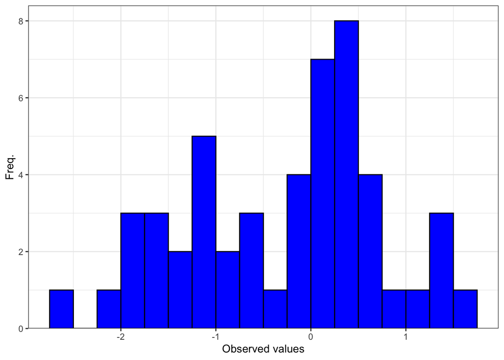

````markdown
```{r}
#| label: fig-simpleHist
#| fig-cap: "Random Sample from Gaussian Distribution"
#| fig-pos: H
#| fig-height: 5
#| fig-alt: !expr get_alt_text(get_last_plot())
#| aria-describedby: simpleHistLD
#| lst-label: lst-figure2
#| lst-cap: "Code Chunk Showing Extracting Alt Text"

# Additional plot showing how to extract the alt text from the plot ----
ggplot(
  data = data.frame(values = rnorm(50, mean = 0, sd = 1)),
  mapping = aes(x = values)
) +
  geom_histogram(
    color = "black",
    fill = "blue",
    binwidth = 0.25,
    closed = "left",
    boundary = 0
  ) +
  scale_y_continuous(
    expand = expansion(mult = c(0, 0.05))
  ) +
  labs(
    x = "Observed values",
    y = "Freq.",
    alt = "Histogram of 50 randomly sampled values from a Gaussian distribution that is symmetric, bell-shaped, and centered around zero."
  ) +
  theme_bw()
```
````

**Long Description**

The vertical axis is labelled 'Freq.' and goes from 0 to 8 with labels of 0, 2, 4, 6 and 8.

Notice in Listing 14 that the `fig-alt` key’s value is the expression `!expr get_alt_text(get_last_plot())`. This set up allows us to call two functions from the `{ggplot2}` package (`get_alt_text` and `get_last_plot`) to apply alt text that we already set in our `ggplot` series of commands.

#### 5.2.1.2 Adding Long Descriptions

We also talked about using Long Descriptions with our plots/graphs. The ASU Image Accessibility tool and the `{BrailleR}` package can generate these descriptions for you. The best thing you can do is incorporate these into your narrative text, and use cross-references to connect the descriptions and figure. You can learn more about [Long Descriptions at Penn State’s Accessibility page](https://accessibility.psu.edu/images/longdescription/) *Long Description* (2015).

For HTML outputs, we can also use the `aria-describedby` option creates a connection between the plot and the long description collapsible text that appears below the plot. If you are interested in learning how to add these collapsible blocks, reach out to me.

**Note**

You are *required* to include alt text (or long descriptions) for your course project as such practices make your reports more inclusive and accessible–principles at the heart of Open Science.

# 6 Cross-referencing

Cross-referencing is the act of referring to an object in your document by a linked name (*Cross References*, n.d.). If you’ve read a text and come across sentences such as “See Figure 1” or “as shown in Table 3.2”, you’ve read sentences the incorporate cross-referencing. Multiple document systems will help you do cross-referencing including Microsoft Word, LaTeX, and Quarto. It is often best to let those systems handle cross-referencing rather than you attempt to do it by hand. The computer is pretty good (better than us) at the tedious aspect of keeping the number all sorted.

## 6.1 Setting Up Elements

The first thing that you have to do if you want to cross-reference elements is you have to make sure that each element you want is *uniquely named*. For Tables and Figures, this is where the `label` code chunk option comes into play. For code chunks, you’ll use the `lst-label` option.

For equations and section headings, you’ll make use of label at the immediate end that is enclosed in curly braces and starts with a hash sign. For example, this sub-section’s heading appears as

`## Setting Up Elements {#sec-setElements}`

in the Quarto document, where`{#sec-setElements}` is the label.

Notice that every name follows a similar naming convention: `prefix-uniqueName`. The `prefix` specifies the cross-reference type and is what Quarto uses to keep track of numbering and add key words. The dash, `-`, separates the prefix from the unique name. When coming up with unique names, be sure to follow good naming practices: no spaces, don’t start with numerals, and avoid special characters–including the underscore.

There are multiple prefix that are built into Quarto. The most common are

- `fig` for Figures
- `tbl` for Tables
- `sec` for Sections (headings)
- `eq` for Equations
- `lst` for (Code) Listings

## 6.2 Making a Cross-Reference

Once you have the items created and appropriately named, you can then reference them in the body of your Quarto document by typing an at symbol, `@`, and then immediately following that by the label for the element you want to refer to. For example, @tbl-diamondsSummary and @fig-namesPlot will let me cross-reference Table 1 and Figure 1 respectively. That’s all there is to making a cross-reference.

# 7 Working with References

Another part of Open Science is making sure that you give credit where credit is due. You should incorporate references as appropriate into your reports. There are two key things that you’ll need for including references: a citation style and a bibliography file.

## 7.1 Citation Style

By default, Quarto will use Chicago citation style but you can change this with the YAML key `csl`. The value you provide to this key is the file name of the Citation Style Language file *that is in the same folder as your Quarto document*. For this Quarto guide, I used `csl: apa7.csl` and I have the `apa7.csl` file with my QMD file.

**Tip**

You can find CSL files for the American Psychological Association’s 7th Ed. (`apa7.csl`) and the Modern Language Association’s 9th Edition (`MLA9.csl`) in the Course Project Guidelines Template Repo.

Alternatively, you can also trigger a download of your desired citation style’s CSL file by entering the URL for the style. For example, entering https://www.zotero.org/styles/apa will trigger a download of the most current APA CSL file. You can browse a full list at https://www.zotero.org/styles/.

## 7.2 Bibliography File

The bibliography file is something that you can create via another application (e.g., BibTeX, EndNote, Mendaly, Zotero) or you can use the built-in tools of RStudio Desktop.

I’m a supporter of [Zotero](https://www.zotero.org/download/) as a reference manager. If you download and install Zotero for your computer, RStudio should automatically detect Zotero and connect with it. To learn more about using Zotero, I recommend the [PSU Libraries Zotero Guide](https://guides.libraries.psu.edu/zotero) (Amsberry, n.d.).

One nice thing about using RStudio’s tools (especially with Zotero) is that this will build the bibliography file for you as you add references to your Quarto document. The auto-generated bibliography file will show up as `references.bib` and appear in the same folder/directory as your QMD file. In your YAML header, you’ll want to make sure that you have the `key: value` pair `bibliography: references.bib`. If your bibliography file is named something else, just change the value to match the file name. (The extensions should still be `bib`.)

## 7.3 Adding References to Your Document

RStudio’s Citation tool is generally only available in the Visual editor mode. However, once you get the hang of the citations, you can start including them in the Source editor mode. Keep in mind that there are generally two ways to have a citation in the body of your report: as a parenthetical and as an in-text citation. The parenthetical will depend upon your citation style and could appear as the name(s) of the author(s) followed by the date both inside a set of parentheses or as a bracketed number. The in-text citation generally lists the author’s last name followed by just the date in parentheses. Here’s an example of the two citation styles.

- Parenthetical: Check out libraries Zotero guide (Amsberry, n.d.).
  - Text in Quarto File: Check out libraries Zotero guide [@amsberry].
- In-text: Amsberry (n.d.) created a useful guide for Zotero.
  - Text in Quarto File: @amsberry created a useful guide for Zotero.

The key to adding a reference to your narrative text is to use the at-sign, @, followed by the citation’s id, just like a cross-reference. Enclosing the cross-reference in square brackets will use the parenthetical style, otherwise you’ll get in-text style.

**Caution**

Be careful when switching back-and-forth between the Source and Visual editor views in RStudio Desktop. Because the Visual editor attempts to render certain elements (e.g., mathematics, divisions surrounded by triple-colons–`:::`), you might find that some of your code appear “hashed” or altered.

## 7.4 The References Section

The last piece for working with references in your reports is to add a Reference Sections (a.k.a. Works Cited or Bibliography). This generally goes at the end of your document and before any appendices. Quarto will automatically build this portion of your document for you if you have used the citations.

To control the location of the references section you’ll want to include the following code (Listing 15) in your Quarto document.

Listing 15: Quarto Commands for Making a Reference Section

{{< pagebreak >}}  
# References

```
::: {#refs}
:::
```

In the first line of Listing 15 will give you a command that will put a page break into your rendered document before starting the references section. You can change the text in the second line from “References” to “Works Cited”, “Bibliography”, or whatever term is appropriate for your chosen writing/citation style. The third and fourth lines should appear as they do in Listing 15.

# 8 Creating a Code Appendix

One of the greatest powers of Quarto is that it can automatically create an appendix of all of your code chunks. This helps keep your work transparent without cluttering the body of your report with distracting code.

Listing 16 shows how you can create a code appendix automatically.

Listing 16: Code Chunk for Creating Code Appendix

{{< pagebreak >}}  
# Code Appendix  
`{r codeAppend, ref.label=knitr::all_labels(), echo=TRUE, eval=FALSE}`

Notice that the commands for the code chunk appear *inside* the curly braces where we specify the programming language.

# 9 References

Amsberry, D. (n.d.). *Library Guides: Zotero: Home–Overview*. https://guides.libraries.psu.edu/zotero/overview

*Cross References*. (n.d.). https://quarto.org/docs/authoring/cross-references.html#overview

*Image ALT text*. (2014). https://accessibility.psu.edu/images/alttext/

Kaplan, D., & Beckman, M. (2020). *Baby Names* [Dataset]. {dcData} R Package. https://github.com/mdbeckman/dcData

*Long description*. (2015). https://accessibility.psu.edu/images/longdescription/

*Markdown Cheat Sheet | Markdown Guide*. (n.d.). https://www.markdownguide.org/cheat-sheet/

Overleaf. (n.d.). *List of Greek letters and math symbols*. Retrieved December 4, 2024, from https://www.overleaf.com/learn/latex/List_of_Greek_letters_and_math_symbols

*Using Python*. (n.d.). https://quarto.org/docs/computations/python.html

Wickham, H. (2015). *Diamonds* (Version 3.5.1) [Dataset]. {ggplot2} R package. https://ggplot2.tidyverse.org/

# 10 Code Appendix

```r
install.packages("tinytex")
library(tinytex)
install_tinytex()

# A First Example Code Chunk ---
1 + 1

# An example python code chunk ----
prefix = "Stat"
num = 184

statement = "Welcome to {} {}!".format(prefix, num)
print(statement)

# Example of Call Python object in R Chunk ----
library(reticulate)
capStatement <- stringr::str_to_upper(py$statement)
print(capStatement)

# Create new R objects for next example ----
mainPart <- runif(n = 5, min = 50, max = 80)
errorPart <- rnorm(n = 5, mean = 0, sd = 1)

# Example of Calling R objects in Python ----
newValues = [sum(x) for x in zip(r.mainPart, r.errorPart)]
roundedValues = [round(x, 3) for x in newValues]
print(roundedValues)

# Load Packages ----
library(tidyverse)
library(knitr)
library(kableExtra)

# Load Data ----
data(diamonds)

# Summarize the diamonds data ----
summaryWidth <- diamonds %>%
  group_by(cut) %>%
  dplyr::select(cut, y) %>%
  filter(y > 0) %>%
  summarize(
    count = n(),
    minimum = min(y, na.rm = TRUE),
    firstQuin = quantile(y, probs = 0.2, na.rm = TRUE),
    secondQuin = quantile(y, probs = 0.4, na.rm = TRUE),
    median = median(y, na.rm = TRUE),
    thirdQuin = quantile(y, probs = 0.6, na.rm = TRUE),
    fourthQuin = quantile(y, probs = 0.8, na.rm = TRUE),
    max = max(y, na.rm = TRUE),
    SAM = mean(y, na.rm = TRUE),
    SASD = sd(y, na.rm = TRUE)
  )

# Make Diamond Summary Table ----
summaryWidth %>%
  kable(
    digits = 2,
    col.names = c("Cut Quality", "Freq.", "Min", "20%-tile", "40%-tile", "Median",
                  "60%-tile", "80%-tile", "Max", "SAM", "SASD"),
    format.args = list(big.mark = ","),
    align = "lcccccccccc"
  ) %>%
  kable_classic() %>%
  add_footnote(
    label = c("Width was measured in milimeters."),
    notation = "none",
    threeparttable = TRUE
  )

# Load Data ----
data("BabyNames", package = "dcData")
# Wrangle Data ----
## Selected names
instructors <- c("Abby", "Edward", "Padma", "Neil")
## Subset and construct counts
subsetNames <- BabyNames %>%
  filter(name %in% instructors) %>%
  group_by(name, year) %>%
  summarize(
    total = sum(count),
    .groups = "drop"
  )

# Set Color Palette ----
psuPalette <- c("#1E407C", "#BC204B", "#3EA39E", "#E98300",
                "#999999", "#AC8DCE", "#F2665E", "#99CC00")

# Make Data Visualization ----
ggplot(
  data = subsetNames,
  mapping = aes(x = year, y = total, color = name, linetype = name)
) +
  geom_line(linewidth = 0.75) +
  theme_bw() +
  labs(
    x = "Year",
    y = "Total Number of People with Name",
    color = "Name",
    linetype = "Name"
  ) +
  theme(
    text = element_text(size = 14),
    legend.key.size = unit(1, 'cm')
  ) +
  scale_color_manual(
    values = psuPalette
  ) +
  scale_y_continuous(
    expand = expansion(mult = 0.01)
  )

# Additional plot showing how to extract the alt text from the plot ----
ggplot(
  data = data.frame(values = rnorm(50, mean = 0, sd = 1)),
  mapping = aes(x = values)
) +
  geom_histogram(
    color = "black",
    fill = "blue",
    binwidth = 0.25,
    closed = "left",
    boundary = 0
  ) +
  scale_y_continuous(
    expand = expansion(mult = c(0, 0.05))
  ) +
  labs(
    x = "Observed values",
    y = "Freq.",
    alt = "Histogram of 50 randomly sampled values from a Gaussian distribution that is symmetric, bell-shaped, and centered around zero."
  ) +
  theme_bw()
```